# R Notebook

# Chapter 15 Statistical Inference

In Chapter 16 we will describe, in some detail, how poll aggregators such as FiveThirtyEight use data to predict election outcomes. To understand how they do this, we first need to learn the basics of *Statistical Inference*, the part of statistics that helps distinguish patterns arising from signal from those arising from chance. Statistical inference is a broad topic and here we go over the very basics using polls as a motivating example. To describe the concepts, we complement the mathematical formulas with Monte Carlo simulations and R code.

## 15.1 Polls

Opinion polling has been conducted since the 19th century. The general goal is to describe the opinions held by a specific population on a given set of topics. In recent times, these polls have been pervasive during presidential elections. (여론 조사인가)

Polls are useful when interviewing every member of a particular population is logistically impossible. The general strategy is to interview a smaller group, chosen at random, and then infer the opinions of the entire population from the opinions of the smaller group. Statistical theory is used to justify the process. This theory is referred to as *inference* and it is the main topic of this chapter. (inference. 추론.)

Perhaps the best known opinion polls are those conducted to determine which candidate is preferred by voters in a given election. Political strategists make extensive use of polls to decide, among other things, how to invest resources. For example, they may want to know in which geographical locations to focus their “get out the vote” efforts. (어느 지역을 조사할 것인가.)

Elections are a particularly interesting case of opinion polls because the actual opinion of the entire population is revealed on election day. Of course, it costs millions of dollars to run an actual election which makes polling a cost effective strategy for those that want to forecast the results. (작은 그룹에 대한 조사 결과를 실제 전체 인구 결과와 비교할 수 있다는 점에서 독특한 듯.)

Although typically the results of these polls are kept private, similar polls are conducted by news organizations because results tend to be of interest to the general public and made public. We will eventually be looking at such data.

Real Clear Politics is an example of a news aggregator that organizes and publishes poll results. For example, they present the following poll results reporting estimates of the popular vote for the 2016 presidential election:

Although in the United States the popular vote does not determine the result of the presidential election, we will use it as an illustrative and simple example of how well polls work. Forecasting the election is a more complex process since it involves combining results from 50 states and DC and we describe it in Section 16.8.

In this section, we will show how the probability concepts we learned in the previous chapter can be applied to develop the statistical approaches that make polls an effective tool. We will learn the statistical concepts necessary to define *estimates* and *margins of errors*, and show how we can use these to forecast final results relatively well and also provide an estimate of the precision of our forecast.

Once we learn this, we will be able to understand two concepts that are ubiquitous in data science: *confidence intervals* and *p-values*. Finally, to understand probabilistic statements about the probability of a candidate winning, we will have to learn about Bayesian modeling. In the final sections, we put it all together to recreate the simplified version of the FiveThirtyEight model and apply it to the 2016 election.

We start by connecting probability theory to the task of using polls to learn about a population.

### 15.1.1 The sampling model for polls

To help us understand the connection between polls and what we have learned, let’s construct a similar situation to the one pollsters face. To mimic the challenge real pollsters face in terms of competing with other pollsters for media attention, we will use an urn full of beads to represent voters and pretend we are competing for a $25 dollar prize. The challenge is to guess the spread between the proportion of blue and red beads in this urn (in this case, a pickle jar):

Before making a prediction, you can take a sample (with replacement) from the urn. To mimic the fact that running polls is expensive, it costs you $0.10 per each bead you sample. Therefore, if your sample size is 250, and you win, you will break even since you will pay $25 to collect your $25 prize. (버는 돈보다 적게 사용해야 한다는 것인가.)

Your entry into the competition can be an interval. If the interval you submit contains the true proportion, you get half what you paid and pass to the second phase of the competition. In the second phase, the entry with the smallest interval is selected as the winner. (interval이 진짜여야 하고 작아야 한다?)

The **dslabs** package includes a function that shows a random draw from this urn:

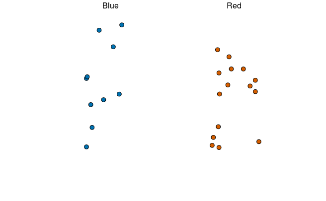

```r
library(tidyverse)
library(dslabs)
take_poll(25)
```

Think about how you would construct your interval based on the data shown above.

We have just described a simple sampling model for opinion polls. The beads inside the urn represent the individuals that will vote on election day. Those that will vote for the Republican candidate are represented with red beads and the Democrats with the blue beads. For simplicity, assume there are no other colors. That is, that there are just two parties: Republican and Democratic.

## 15.2 Populations, samples, parameters, and estimates

We want to predict the proportion of blue beads in the urn. Let’s call this quantity $p$, which then tells us the proportion of red beads $1-p$, and the spread $p - (1-p)$, which simplifies to $2p-1$. (spread는 proportion의 차..)

In statistical textbooks, the beads in the urn are called the *population*. The proportion of blue beads in the population $p$ is called a *parameter*. The 25 beads we see in the previous plot are called a *sample*. The task of statistical inference is to predict the parameter $p$ using the observed data in the sample.

(여러 sample plot)

### 15.2.1 The sample average

Conducting an opinion poll is being modeled as taking a random sample from an urn. We are proposing the use of the proportion of blue beads in our sample as an estimate of the parameter $p$. Once we have this estimate, we can easily report an estimate for the spread $2p-1$, but for simplicity we will illustrate the concepts for estimating $p$. We will use our knowledge of probability to defend our use of the sample proportion and quantify how close we think it is from the population proportion $p$. (샘플 확률과 p가 얼마나 가까운가?)

We start by defining the random variable $X$ as: $X=1$ if we pick a blue bead at random and $X=0$ if it is red. This implies that the population is a list of 0s and 1s. If we sample $N$ beads, then the average of the draws $X_1,…,X_N$ is equivalent to the proportion of blue beads in our sample. This is because adding the $X$s is equivalent to counting the blue beads and dividing this count by the total $N$ is equivalent to computing a proportion. We use the symbol $X'$ to represent this average. In general, in statistics textbooks a bar on top of a symbol means the average. The theory we just learned about the sum of draws becomes useful because the average is a sum of draws multiplied by the constant $1/N$: (블루 비드가 1. 1의 모음, 즉 X의 합이 블루 비드 개수. 전체 분의 블루 비드 개수가 블루 비드의 proportion.) (X위에 -가 있는 것이 평균. 편의상 X’라고 표현하겠음..)

$X'=1/N×∑(N)(i=1)(X_i)$

For simplicity, let’s assume that the draws are independent: after we see each sampled bead, we return it to the urn. In this case, what do we know about the distribution of the sum of draws? First, we know that the expected value of the sum of draws is $N$ times the average of the values in the urn. We know that the average of the 0s and 1s in the urn must be $p$, the proportion of blue beads. (the sum of draws = (블루 비드 개수)/(전체) * N = the average * N)

Here we encounter an important difference with what we did in the Probability chapter: we don’t know what is in the urn. We know there are blue and red beads, but we don’t know how many of each. This is what we want to find out: we are trying to **estimate $p$**.

### 15.2.2 Parameters

Just like we use variables to define unknowns in systems of equations, in statistical inference we define *parameters* to define unknown parts of our models. In the urn model which we are using to mimic an opinion poll, we do not know the proportion of blue beads in the urn. We define the parameters $p$ to represent this quantity. $p$ is the average of the urn because if we take the average of the 1s (blue) and 0s (red), we get the proportion of blue beads. Since our main goal is figuring out what is $p$, we are going to *estimate this parameter*.

The ideas presented here on how we estimate parameters, and provide insights into how good these estimates are, extrapolate to many data science tasks. For example, we may want to determine the difference in health improvement between patients receiving treatment and a control group. We may ask, what are the health effects of smoking on a population? What are the differences in racial groups of fatal shootings by police? What is the rate of change in life expectancy in the US during the last 10 years? All these questions can be framed as a task of estimating a parameter from a sample. (extrapolate 추론하다)

### 15.2.3 Polling versus forecasting

Before we continue, let’s make an important clarification related to the practical problem of forecasting the election. If a poll is conducted four months before the election, it is estimating the $p$ for that moment and not for election day. The $p$ for election night might be different since people’s opinions fluctuate through time. The polls provided the night before the election tend to be the most accurate since opinions don’t change that much in a day. However, forecasters try to build tools that model how opinions vary across time and try to predict the election night results taking into consideration the fact that opinions fluctuate. We will describe some approaches for doing this in a later section. (시간에 따라 의견이 변화하는 것도 변수로 취급?)

### 15.2.4 Properties of our estimate: expected value and standard error

To understand how good our estimate is, we will describe the statistical properties of the random variable defined above: the sample proportion $X'$. Remember that $X'$ is the sum of independent draws so the rules we covered in the probability chapter apply.

Using what we have learned, the expected value of the sum $NX'$ is $N×$ the average of the urn, $p$. So dividing by the non-random constant $N$ gives us that the expected value of the average $X'$ is $p$. We can write it using our mathematical notation:

$E(X') = p$

We can also use what we learned to figure out the standard error: the standard error of the sum is $√N×$ the standard deviation of the urn. Can we compute the standard error of the urn? We learned a formula that tells us that it is $(1−0)√p(1−p) = √p(1−p)$. Because we are dividing the sum by $N$, we arrive at the following formula for the standard error of the average:

$SE(X') = √p(1−p)/N$ (음..)

This result reveals the power of polls. The expected value of the sample proportion $X$ is the parameter of interest $p$ and we can make the standard error as small as we want by increasing $N$. The law of large numbers tells us that with a large enough poll, our estimate converges to $p$. (N이 크면 SE(X’) 줄어들고.. 우리는 p를 구하는 거니까? 그냥 X였다면.. 안 줄었겠지?)

If we take a large enough poll to make our standard error about 1%, we will be quite certain about who will win. But how large does the poll have to be for the standard error to be this small?

One problem is that we do not know $p$, so we can’t compute the standard error. However, for illustrative purposes, let’s assume that $p=0.51$ and make a plot of the standard error versus the sample size $N$: (p를 모르므로 SE를 계산할 수가 없어..!)

```r
p<-0.51
sqrt(p*(1-p))/sqrt(1000)
```

```
[1] 0.01580823
```

```
#> [1] 0.0158
```

or 1.5 percentage points. So even with large polls, for close elections, $X'$ can lead us astray if we don’t realize it is a random variable. Nonetheless, we can actually say more about how close we get the $p$ and we do that in Section. (astray 잘못된 길로 빠지게 함)

## 15.3 Exercises

1. Suppose you poll a population in which a proportion $p$ of voters are Democrats and $1 - p$ are Republicans. Your sample size is $N = 25$. Consider the random variable $S$ which is the **total** number of Democrats in your sample. What is the expected value of this random variable? Hint: it’s a function of $p$.

```r
N <- 25
S <- N*p
N*p*N/N
```

```
[1] 12.75
```

**N*p**

2. What is the standard error of $S$ ? Hint: it’s a function of $p$.

**√(N*p*(1-p))**

3. Consider the random variable $S/N$. This is equivalent to the sample average, which we have been denoting as $X'$. What is the expected value of the $X$? Hint: it’s a function of $p$.

**p**

4. What is the standard error of $X'$? Hint: it’s a function of $p$.

**√(p*(1-p)/N)**

5. Write a line of code that gives you the standard error `se` for the problem above for several values of $p$, specifically for `p <- seq(0, 1, length = 100)`. Make a plot of `se` versus `p`.

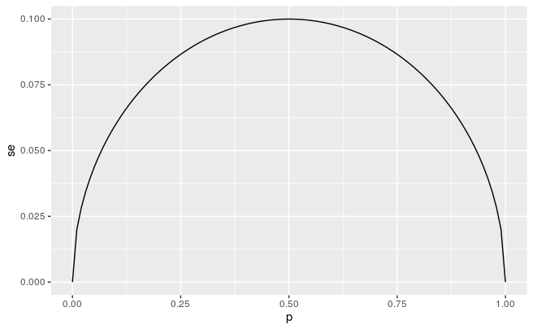

```r
N <- 25
p <- seq(0, 1, length = 100)
se <- sqrt(p*(1-p)/N)

mk <- data.frame(p = p, se = se)

ggplot(mk) + geom_line(aes(x = p, y = se))
```

??

6. Copy the code above and put it inside a for-loop to make the plot for $N=25$, $N=100$, and $N=1000$.

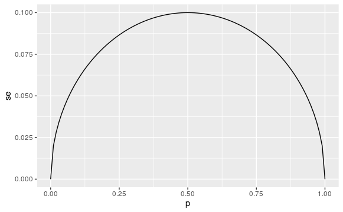

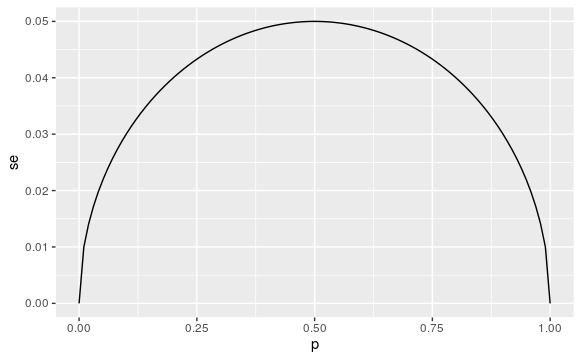

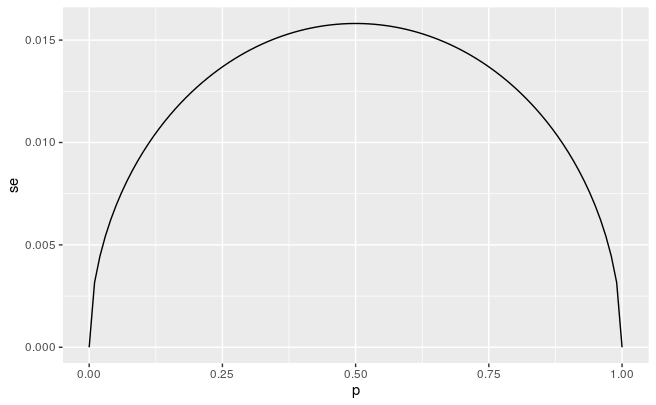

```r
N <- c(25, 100, 1000)

for(X in 1:3){
  p <- seq(0, 1, length = 100)
  se <- sqrt(p*(1-p)/N[X])

  mk <- data.frame(p = p, se = se)

  print(ggplot(mk) + geom_line(aes(x = p, y = se)))
}
```

```r
#print를 꼭 써줘야 하는군?
#for(X in c(1, 2, 3))도 되는 듯
```

(SE 줄어들고 있다?)

7. If we are interested in the difference in proportions, $p−(1−p)$, our estimate is $d=X'−(1−X')$. Use the rules we learned about sums of random variables and scaled random variables to derive the expected value of $d$.

```r
d <- 2*p - 1
N*sum(d)/length(d)
```

```
[1] 1.998401e-15 7.993606e-15 7.993606e-14
```

**1.998401e-15**

N*sum(d)/length(d)

8. What is the standard error of $d$?

```r
sqrt(N)*sqrt(abs(d*(1-d)))
```

```
longer object length is not a multiple of shorter object length
```

[output not shown]

9. If the actual $p=.45$, it means the Republicans are winning by a relatively large margin since $d=−.1$, which is a 10% margin of victory. In this case, what is the standard error of $2X−1$ if we take a sample of $N=25$?

```r
N<-25
p <- 0.45
d <- -0.1
sqrt(d*(1-d))/sqrt(N)
```

```
NaNs produced
```

```
[1] NaN
```

```r
X_X <- sample(c(1, 0), size = N, replace = TRUE, prob = c(p, 1-p))
X_bar <- mean(X_X)
margin <- 2*X_bar - 1
sqrt(margin*(1-margin)/N)
```

```
NaNs produced
```

```
[1] NaN
```

```r
X_etc <- X_X*2 -1
sd(X_etc)
```

```
[1] 1.013246
```

(?)

10. Given the answer to 9, which of the following best describes your strategy of using a sample size of $N=25$?
1. The expected value of our estimate $2X−1$ is $d$, so our prediction will be right on. **b**. Our standard error is larger than the difference, so the chances of $2X−1$ being positive and throwing us off were not that small. We should pick a larger sample size.
2. The difference is 10% and the standard error is about 0.2, therefore much smaller than the difference.
3. Because we don’t know $p$, we have no way of knowing that making $N$ larger would actually improve our standard error.

## 15.4 Central Limit Theorem in practice

The CLT tells us that the distribution function for a sum of draws is approximately normal. We also learned that dividing a normally distributed random variable by a constant is also a normally distributed variable. This implies that the distribution of $X'$ is approximately normal. (정상분포다..?)

In summary, we have that $X'$ has an approximately normal distribution with expected value $p$ and standard error $√p(1−p)/N$.

Now how does this help us? Suppose we want to know what is the probability that we are within 1% from $p$. We are basically asking what is (p가.. 모집단 비율인 거지..?)

$Pr(|X'−p|≤.01)$

which is the same as:

$Pr(X'≤p+.01)−Pr(X'≤p−.01)$ (p로부터 0.01 플러스 마이너스)

Can we answer this question? We can use the mathematical trick we learned in the previous chapter. Subtract the expected value and divide by the standard error to get a standard normal random variable, call it $Z$, on the left. Since $p$ is the expected value and $SE(X')=√p(1−p)/N$ is the standard error we get:

$Pr(Z≤(.01/SE(X'))) - Pr(Z≤(-.01/SE(X')))$

One problem we have is that since we don’t know $p$, we don’t know $SE(X)$. But it turns out that the CLT still works if we estimate the standard error by using $X$ in place of $p$. We say that we *plug-in* the estimate. Our estimate of the standard error is therefore: (X’를 p 대신 써도 된다..)

$SE(X')=√(X'(1−X')/N)$

In statistics textbooks, we use a little hat to denote estimates. The estimate can be constructed using the observed data and $N$. (estimates 위에 작은 꼬깔 표시 있음.)

```r
x_hat <- 0.48
se <- sqrt(x_hat*(1-x_hat)/25)
se
```

```
[1] 0.09991997
```

```
#> [1] 0.0999
```

And now we can answer the question of the probability of being close to $p$. The answer is:

```r
pnorm(0.01/se) - pnorm(-0.01/se)
```

```
[1] 0.07971926
```

```
#> [1] 0.0797
```

Therefore, there is a small chance that we will be close. A poll of only $N=25$ people is not really very useful, at least not for a close election.

```r
1.96*se
```

```
[1] 0.1958431
```

```
#> [1] 0.196
```

Why do we multiply by 1.96? Because if you ask what is the probability that we are within 1.96 standard errors from $p$, we get:

$Pr(Z≤1.96SE(X')/SE(X'))−Pr(Z≤−1.96SE(X')/SE(X'))$

which is:

$Pr(Z≤1.96)−Pr(Z≤−1.96)$

which we know is about 95%:

```r
pnorm(1.96)-pnorm(-1.96)
```

```
[1] 0.9500042
```

```
#> [1] 0.95
```

Hence, there is a 95% probability that $X'$ will be within $1.96×SE(X')$, in our case within about 0.2, of $p$. Note that 95% is somewhat of an arbitrary choice and sometimes other percentages are used, but it is the most commonly used value to define margin of error. We often round 1.96 up to 2 for simplicity of presentation.

In summary, the CLT tells us that our poll based on a sample size of $25$ is not very useful. We don’t really learn much when the margin of error is this large. All we can really say is that the popular vote will not be won by a large margin. This is why pollsters tend to use larger sample sizes.

### 15.4.1 A Monte Carlo simulation

Suppose we want to use a Monte Carlo simulation to corroborate the tools we have built using probability theory. To create the simulation, we would write code like this:

```r
B <- 10000
N <- 1000
x_hat <- replicate(B, {
  x <- sample(c(0,1), size = N, replace = TRUE, prob = c(1-p, p))
  mean(x)
})
```

The problem is, of course, we don’t know `p`. We could construct an urn like the one pictured above and run an analog (without a computer) simulation. It would take a long time, but you could take 10,000 samples, count the beads and keep track of the proportions of blue. We can use the function `take_poll(n=1000)` instead of drawing from an actual urn, but it would still take time to count the beads and enter the results.

One thing we therefore do to corroborate theoretical results is to pick one or several values of `p` and run the simulations. Let’s set `p=0.45`. We can then simulate a poll:

```r
p <- 0.45
N <- 1000

x <- sample(c(0,1), size = N, replace = TRUE, prob = c(1-p, p))
x_hat <- mean(x)
```

In this particular sample, our estimate is `x_hat`. We can use that code to do a Monte Carlo simulation:

```r
B <- 10000
x_hat <- replicate(B, {
  x <- sample(c(0,1), size = N, replace = TRUE, prob = c(1-p, p))
  mean(x)
})
```

To review, the theory tells us that $X$ is approximately normally distributed, has expected value $p=$ 0.45 and standard error $√p(1−p)/N$ = 0.016. The simulation confirms this:

```r
mean(x_hat)
```

```
[1] 0.4500557
```

```
#> [1] 0.45
```

```r
sd(x_hat)
```

```
[1] 0.01571206
```

```
#> [1] 0.0157
```

A histogram and qq-plot confirm that the normal approximation is accurate as well:

[figure not shown]

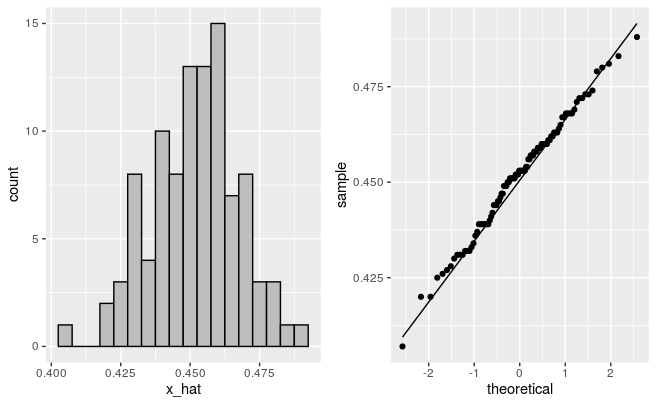

```r
B <- 100
x_hat <- replicate(B, {
  x <- sample(c(0,1), size = N, replace = TRUE, prob = c(1-p, p))
  mean(x)
})

p3 <- data.frame(x_hat) %>% ggplot(aes(x = x_hat)) + geom_histogram(binwidth = 0.005, color = "black", fill = "gray")
p4 <- data.frame(x_hat) %>% ggplot() + geom_qq(aes(sample = x_hat))+ geom_qq_line(aes(sample = x_hat))
plot_grid(p3, p4)
```

```r
# B가 10, 100, 1000... normal distribution 같음..
```

(그래프)

Of course, in real life we would never be able to run such an experiment because we don’t know $p$. But we could run it for various values of $p$ and $N$ and see that the theory does indeed work well for most values. You can easily do this by re-running the code above after changing `p` and `N`.

### 15.4.2 The spread

The competition is to predict the spread, not the proportion $p$. However, because we are assuming there are only two parties, we know that the spread is $p−(1−p)=2p−1$. As a result, everything we have done can easily be adapted to an estimate of $2p−1$. Once we have our estimate $X'$ and $SE(X')$, we estimate the spread with $2X'−1$ and, since we are multiplying by 2, the standard error is $2SE(X')$. Note that subtracting 1 does not add any variability so it does not affect the standard error. (-1은 SE에 영향 없다..)

### 15.4.3 Bias: why not run a very large poll?

(그래프)

One reason is that running such a poll is very expensive. Another possibly more important reason is that theory has its limitations. Polling is much more complicated than picking beads from an urn. Some people might lie to pollsters and others might not have phones. But perhaps the most important way an actual poll differs from an urn model is that we actually don’t know for sure who is in our population and who is not. How do we know who is going to vote? Are we reaching all possible voters? Hence, even if our margin of error is very small, it might not be exactly right that our expected value is $p$. We call this bias. Historically, we observe that polls are indeed biased, although not by that much. The typical bias appears to be about 1-2%. This makes election forecasting a bit more interesting and we will talk about how to model this in a later chapter.

## 15.5 Exercises

1. Write an *urn model* function that takes the proportion of Democrats $p$ and the sample size $N$ as arguments and returns the sample average if Democrats are 1s and Republicans are 0s. Call the function `take_sample`.

```r
take_sample <- function(){
  x <- sample(c(0,1), size = N, replace = TRUE, prob = c(1-p, p))
  mean(x)
}
```

2. Now assume `p <- 0.45` and that your sample size is $N=100$. Take a sample 10,000 times and save the vector of `mean(X) - p` into an object called `errors`. Hint: use the function you wrote for exercise 1 to write this in one line of code.

```r
p <- 0.45
N <- 100
B <- 10000
errors <- replicate(B, take_sample())
erros <- errors - p
```

(replicate의 argument func에 () 안 붙이면 list가 되는군?)

3. The vector `errors` contains, for each simulated sample, the difference between the actual $p$ and our estimate $X$. We refer to this difference as the *error*. Compute the average and make a histogram of the errors generated in the Monte Carlo simulation and select which of the following best describes their distributions:

```r
mean(errors)
```

```
[1] 0.4496
```

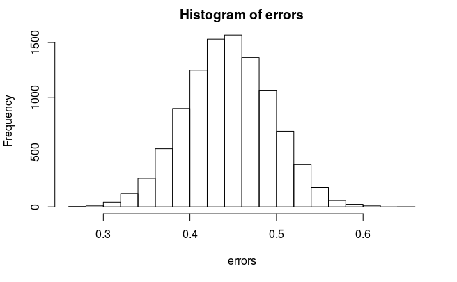

```r
hist(errors)
```

4. The error $X - p$ is a random variable. In practice, the error is not observed because we do not know $p$. Here we observe it because we constructed the simulation. What is the average size of the error if we define the size by taking the absolute value $|X - p|$?

```r
mean(abs(errors))
```

```
[1] 0.4496
```

bigger..

5. The standard error is related to the typical **size** of the error we make when predicting. We say **size** because we just saw that the errors are centered around 0, so thus the average error value is 0. For mathematical reasons related to the Central Limit Theorem, we actually use the standard deviation of `errors` rather than the average of the absolute values to quantify the typical size. What is this standard deviation of the errors?

```r
sd(errors)
```

```
[1] 0.0499963
```

**0.0499963**

6. The theory we just learned tells us what this standard deviation is going to be because it is the standard error of $X$. What does theory tell us is the standard error of $X$ for a sample size of 100?

```r
sqrt(p*(1-p)/N)
```

```
[1] 0.04974937
```

**0.04974937**

7. In practice, we don’t know $p$, so we construct an estimate of the theoretical prediction based by plugging in $X'$ for $p$. Compute this estimate. Set the seed at 1 with `set.seed(1)`.

```r
set.seed(1)
X_hat <- take_sample()
sqrt(X_hat*(1-X_hat)/N)
```

```
[1] 0.04983974
```

**0.04983974**

(sd, p, X_hat 사용 ~> 다 비슷 SE.)

8. Note how close the standard error estimates obtained from the Monte Carlo simulation (exercise 5), the theoretical prediction (exercise 6), and the estimate of the theoretical prediction (exercise 7) are. The theory is working and it gives us a practical approach to knowing the typical error we will make if we predict $p$ with $X'$. Another advantage that the theoretical result provides is that it gives an idea of how large a sample size is required to obtain the precision we need. Earlier we learned that the largest standard errors occur for $p = 0.5$. Create a plot of the largest standard error for $N$ ranging from 100 to 5,000. Based on this plot, how large does the sample size have to be to have a standard error of about 1%?

```r
library(ggplot2)
library(tidyverse)
```

*1.using sd()*

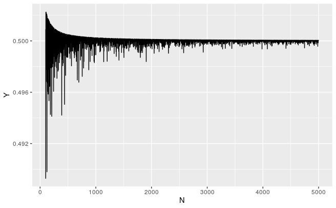

```r
take_sd <- function(N){
  x <- sample(c(0,1), size = N, replace = TRUE, prob = c(1-p, p))
  sd(x)
}

p <- 0.5
N <- 100:5000
gre <- sapply(N, take_sd)
gre. <- data.frame(N = N, Y = gre)
gre. %>% ggplot(aes(x = N, y = Y)) + geom_line()
```

(weird….weird..)

*2.using p*

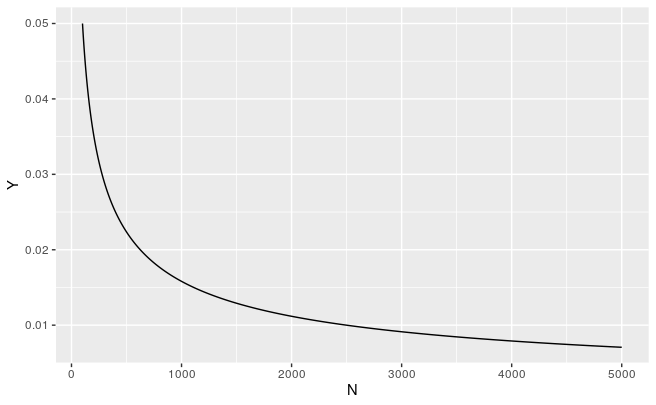

```r
take_sample_2 <- function(N){
  x <- sample(c(0,1), size = N, replace = TRUE, prob = c(1-p, p))
  mean(x)
}
p <- 0.5
N <- 100:5000
grt <- sapply(N, take_sample_2)
data.grt <- data.frame(N = N, Y = sqrt(p*(1-p)/N))
ggplot(data.grt) + geom_line(aes(x = N, y = Y))
```

*3.using X_hat*

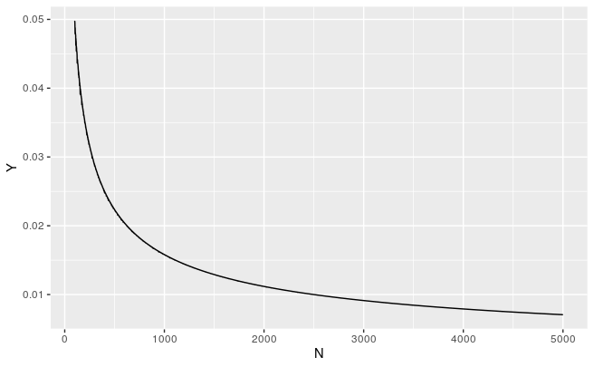

```r
grr <- sapply(N, take_sample_2)
data.grr <- data.frame(N = N, Y = sqrt(grr*(1-grr)/N))
ggplot(data.grr) + geom_line(aes(x = N, y = Y))
```

1. 100
2. 500 **c**. 2,500
3. 4,000

**c**

(X_hat과 p를 사용했을 때 매우 비슷하게 플롯. sd()는 이상함..)

9. For sample size $N = 100$, the central limit theorem tells us that the distribution of $X$ is:
1. practically equal to $p$. **b**. approximately normal with expected value $p$ and standard error $√p(1−p)/N$.
2. approximately normal with expected value $X$ and standard error $√X(1−X)/N$.
3. not a random variable.
10. Based on the answer from exercise 8, the error $X - p$ is:
1. practically equal to 0.
2. approximately normal with expected value $0$ and standard error $√p(1−p)/N$.
3. approximately normal with expected value $p$ and standard error $√p(1−p)/N$.
4. not a random variable.

(exercise 3이 아니고..?)

11. To corroborate your answer to exercise 9, make a qq-plot of the `errors` you generated in exercise 2 to see if they follow a normal distribution.

(check if the data follows specific distribution..)

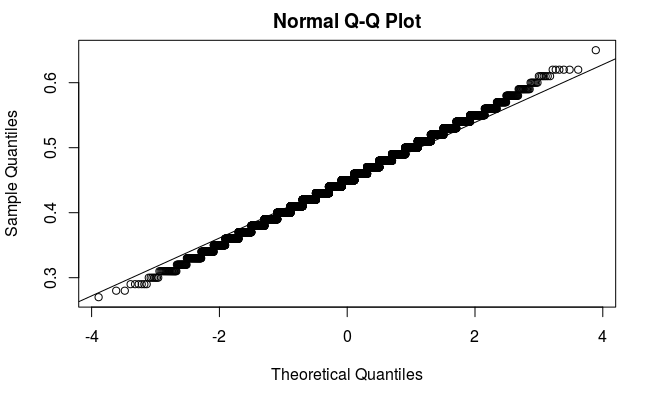

```r
qqnorm(errors)
qqline(errors)
```

12. If $p = 0.45$ and $N = 100$ as in exercise 2, use the CLT to estimate the probability that $X > 0.5$. You can assume you know $p = 0.45$ for this calculation.

```r
p <- 0.45
N <- 100
m <- p
sd <- sqrt(p*(1-p)/N)
1-pnorm(0.5, m, sd)
```

```
[1] 0.1574393
```

**0.1574393**

13. Assume you are in a practical situation and you don’t know $p$. Take a sample of size $N = 100$ and obtain a sample average of $X = 0.51$. What is the CLT approximation for the probability that your error is equal to or larger than 0.01?

error = |X’ - p| 인가? Pr(X >= p + 0.01) Pr(X <= p - 0.01)

```r
N <- 100
X_hat <- 0.51
SE <- sqrt(X_hat*(1-X_hat)/N)
pnorm(-0.01/SE) + 1 - pnorm(0.01/SE)
```

```
[1] 0.8414493
```

**0.8414493**

## 15.6 Confidence intervals

In our earlier competition, you were asked to give an interval. If the interval you submitted includes the $p$, you get half the money you spent on your “poll” back and pass to the next stage of the competition. One way to pass to the second round is to report a very large interval. For example, the interval $[0,1]$ is guaranteed to include $p$.

However, with an interval this big, we have no chance of winning the competition. Similarly, if you are an election forecaster and predict the spread will be between -100% and 100%, you will be ridiculed for stating the obvious. Even a smaller interval, such as saying the spread will be between -10 and 10%, will not be considered serious.

On the other hand, the smaller the interval we report, the smaller our chances are of winning the prize. Likewise, a bold pollster that reports very small intervals and misses the mark most of the time will not be considered a good pollster. We want to be somewhere in between.

We can use the statistical theory we have learned to compute the probability of any given interval including $p$. If we are asked to create an interval with, say, a 95% chance of including $p$, we can do that as well. These are called 95% confidence intervals. (95% 확률로 p를 포함하는 범위)

When a pollster reports an estimate and a margin of error, they are, in a way, reporting a 95% confidence interval. Let’s show how this works mathematically.

We want to know the probability that the interval $[X - 2SE(X), X - 2SE(X)]$ contains the true proportion $p$. First, consider that the start and end of these intervals are random variables: every time we take a sample, they change. To illustrate this, run the Monte Carlo simulation above twice. We use the same parameters as above:

```r
p <- 0.45
N <- 1000
```

And notice that the interval here:

```r
x <- sample(c(0, 1), size = N, replace = TRUE, prob = c(1-p, p))
x_hat <- mean(x)
se_hat <- sqrt(x_hat * (1 - x_hat) / N)
c(x_hat - 1.96 * se_hat, x_hat + 1.96 * se_hat)
```

```
[1] 0.4590159 0.5209841
```

[output not shown]

is different from this one:

```r
x <- sample(c(0,1), size=N, replace=TRUE, prob=c(1-p, p))
x_hat <- mean(x)
se_hat <- sqrt(x_hat * (1 - x_hat) / N)
c(x_hat - 1.96 * se_hat, x_hat + 1.96 * se_hat)
```

```
[1] 0.448037 0.509963
```

[output not shown]

Keep sampling and creating intervals and you will see the random variation.

To determine the probability that the interval includes $p$, we need to compute this:

$Pr(X - 1.96SE(X) ≤ p ≤ X + 1.96SE(X))$

(이 범위 안에 p가 있을 확률은 95%.)

By subtracting and dividing the same quantities in all parts of the equation, we get that the above is equivalent to:

$Pr(-1.96 ≤ (X-p)/(SE(X)) ≤ 1.96 )$

The term in the middle is an approximately normal random variable with expected value 0 and standard error 1, which we have been denoting with $Z$, so we have:

$Pr(-1.96 ≤ Z ≤ 1.96)$

which we can quickly compute using :

```r
pnorm(1.96) - pnorm(-1.96)
```

```
[1] 0.9500042
```

```
#> [1] 0.95
```

proving that we have a 95% probability.

If we want to have a larger probability, say 99%, we need to multiply by whatever `z` satisfies the following:

$Pr(-z ≤ Z ≤ z) = 0.99$

(이 z는 SE(X)에 곱할 숫자 아님?)

Using:

```r
z <- qnorm(0.995)
z
```

```
[1] 2.575829
```

```
#> [1] 2.58
```

( Pr(X<=z) = 0.995 & Pr(X<=-z) = 0.005 )

```r
pnorm(1-qnorm(0.995))
```

```
[1] 0.05753257
```

```r
pnorm(-qnorm(0.995))
```

```
[1] 0.005
```

```r
pnorm(z) - pnorm(-z)
```

```
[1] 0.99
```

```
#> [1] 0.99
```

is `0.995 - 0.005 = 0.99`. We can use this approach for any proportion $p$: we set `z = qnorm(1 - (1 - p)/2)` because $1−(1−p)/2+(1−p)/2=p$.?? 1-(1-p)/2-(1-p)/2 = p라는 뜻이었을까?

z = qnorm(1 - (1 - p)/2). 즉 p라는 확률이 있고. 그걸 1-p한 값이 있고. 이걸 2개로 나누어 양쪽 끝에 분배할 것이므로 왼쪽 끝은 qnorm((1-p)/2)=-z 가 되고. 오른쪽 끝은 qnorm(1-(1-p)/2)=z 가 된다.

So, for example, for $p=0.95$, $1−(1−p)/2=0.975$ and we get the 1.96 we have been using:

```r
qnorm(0.975)
```

```
[1] 1.959964
```

```
#> [1] 1.96
```

### 15.6.1 A Monte Carlo simulation

We can run a Monte Carlo simulation to confirm that, in fact, a 95% confidence interval includes $p$ 95% of the time.

```r
N <- 1000
B <- 10000
inside <- replicate(B, {
  x <- sample(c(0,1), size = N, replace = TRUE, prob = c(1-p, p))
  x_hat <- mean(x)
  se_hat <- sqrt(x_hat * (1 - x_hat) / N)
  between(p, x_hat - 1.96 * se_hat, x_hat + 1.96 * se_hat)
})
mean(inside)
```

```
[1] 0.9477
```

```
#> [1] 0.948
```

(실제로 해보니 그렇더라..)

```r
dim(inside)
```

[output not shown]

[figure not shown]

[figure not shown]

[figure not shown]

```r
p
```

[output not shown]

```r
library(ggplot2)
library(dplyr)
library(hrbrthemes)
```

[output not shown]

[output cut: 990 more lines]

### 15.6.2 The correct language

(여기서 p는 샘플의 비율 아니고 urn의 비율 아니냐구..) (p가 범위에 들어갈 확률이 95%가 아니고, 범위 안에 p가 있을 확률이 95%.. 음 맞나?)

## 15.7 Exercises

For these exercises, we will use actual polls from the 2016 election. You can load the data from the **dslabs** package.

```r
library(dslabs)
data("polls_us_election_2016")
```

Specifically, we will use all the national polls that ended within one week before the election.

```r
library(tidyverse)
polls <- polls_us_election_2016 %>%
  filter(enddate >= "2016-10-31" & state == "U.S.")
```

1. For the first poll, you can obtain the samples size and estimated Clinton percentage with:

```r
#the first sample
N <- polls$samplesize[1]
x_hat <- polls$rawpoll_clinton[1]/100
```

Assume there are only two candidates and construct a 95% confidence interval for the election night proportion $p$.

```r
se_hat <- sqrt(x_hat * (1 - x_hat) / N)
c(x_hat - 1.96 * se_hat, x_hat + 1.96 * se_hat)
```

```
[1] 0.4492381 0.4907619
```

**[0.4492381, 0.4907619]**

2. Now use `dplyr` to add a confidence interval as two columns, call them `lower` and `upper`, to the object `poll`. Then use `select` to show the `pollster`, `enddate`, `x_hat`, `lower`, `upper` variables. Hint: define temporary columns `x_hat` and `se_hat`. (poll? polls? new object poll..?)

```r
library(dplyr)

N <- polls$samplesize
x_hat <- polls$rawpoll_clinton/100
se_hat <- sqrt(x_hat * (1 - x_hat) / N)
lower <- x_hat - 1.96 * se_hat
upper <- x_hat + 1.96 * se_hat


polls <- polls %>% mutate(lower = lower, upper = upper, x_hat = x_hat) %>% select(pollster, enddate, x_hat, lower, upper)
polls
```

| pollster | enddate | x_hat | lower | upper |
| --- | --- | --- | --- | --- |
| ABC News/Washington Post | 2016-11-06 | 0.4700 | 0.4492381 | 0.4907619 |
| Google Consumer Surveys | 2016-11-07 | 0.3803 | 0.3744631 | 0.3861369 |
| Ipsos | 2016-11-06 | 0.4200 | 0.3993520 | 0.4406480 |
| YouGov | 2016-11-07 | 0.4500 | 0.4339196 | 0.4660804 |
| Gravis Marketing | 2016-11-06 | 0.4700 | 0.4624163 | 0.4775837 |
| Fox News/Anderson Robbins Research/Shaw & Company Research | 2016-11-06 | 0.4800 | 0.4527891 | 0.5072109 |
| CBS News/New York Times | 2016-11-06 | 0.4500 | 0.4241784 | 0.4758216 |
| NBC News/Wall Street Journal | 2016-11-05 | 0.4400 | 0.4128273 | 0.4671727 |
| IBD/TIPP | 2016-11-07 | 0.4120 | 0.3830052 | 0.4409948 |
| Selzer & Company | 2016-11-06 | 0.4400 | 0.4055806 | 0.4744194 |

[output cut: 60 more lines]

3. The final tally for the popular vote was Clinton 48.2% and Trump 46.1%. Add a column, call it `hit`, to the previous table stating if the confidence interval included the true proportion $p=0.482$ or not.

```r
p <- 0.482

#return "Succeed" if the random interval falls on top of p
ahem <- function(i){
  T <- between(p, lower[i], upper[i])
  ifelse(T == "TRUE", "Succeed", "Fail")
}

hit <- sapply(1:length(lower), ahem)

polls <-polls %>% mutate(hit = hit)
polls
```

| pollster | enddate | x_hat | lower | upper | hit |
| --- | --- | --- | --- | --- | --- |
| ABC News/Washington Post | 2016-11-06 | 0.4700 | 0.4492381 | 0.4907619 | Succeed |
| Google Consumer Surveys | 2016-11-07 | 0.3803 | 0.3744631 | 0.3861369 | Fail |
| Ipsos | 2016-11-06 | 0.4200 | 0.3993520 | 0.4406480 | Fail |
| YouGov | 2016-11-07 | 0.4500 | 0.4339196 | 0.4660804 | Fail |
| Gravis Marketing | 2016-11-06 | 0.4700 | 0.4624163 | 0.4775837 | Fail |
| Fox News/Anderson Robbins Research/Shaw & Company Research | 2016-11-06 | 0.4800 | 0.4527891 | 0.5072109 | Succeed |
| CBS News/New York Times | 2016-11-06 | 0.4500 | 0.4241784 | 0.4758216 | Fail |
| NBC News/Wall Street Journal | 2016-11-05 | 0.4400 | 0.4128273 | 0.4671727 | Fail |
| IBD/TIPP | 2016-11-07 | 0.4120 | 0.3830052 | 0.4409948 | Fail |
| Selzer & Company | 2016-11-06 | 0.4400 | 0.4055806 | 0.4744194 | Fail |

[output cut: 60 more lines]

4. For the table you just created, what proportion of confidence intervals included $p$?

```r
mean(polls$hit == "Succeed")
```

```
[1] 0.3142857
```

**0.3142857**

5. If these confidence intervals are constructed correctly, and the theory holds up, what proportion should include $p$?

```r
#To determine the probability that the interval includes p
pnorm(1.96) - pnorm(-1.96)
```

```
[1] 0.9500042
```

**0.9500042**

6. A much smaller proportion of the polls than expected produce confidence intervals containing $p$. If you look closely at the table, you will see that most polls that fail to include $p$ are underestimating. The reason for this is undecided voters, individuals polled that do not yet know who they will vote for or do not want to say. Because, historically, undecideds divide evenly between the two main candidates on election day, it is more informative to estimate the spread or the difference between the proportion of two candidates $d$, which in this election was $0.482 - 0.461 = 0.021$. Assume that there are only two parties and that $d = 2p -1$, redefine `polls` as below and re-do exercise 1, but for the difference.

```r
polls <- polls_us_election_2016 %>%
  filter(enddate >= "2016-10-31" & state == "U.S.")  %>%
  mutate(d_hat = rawpoll_clinton / 100 - rawpoll_trump / 100)
```

```r
N <- polls$samplesize
d_hat <- polls$d_hat
x_hat <- polls$rawpoll_clinton/100
se_hat <- 2*sqrt((x_hat) * (1 - x_hat) / N)
c(d_hat - 1.96 * se_hat, d_hat + 1.96 * se_hat)
```

```
  [1] -0.0015237381  0.0117262198 -0.0112959486  0.0078391992
  [5]  0.0248326636 -0.0144218716 -0.0116432905 -0.0143453520
  [9] -0.0729895218 -0.0388387585 -0.0177258977 -0.0116646976
 [13] -0.0534661994  0.0111592823 -0.0679578994 -0.0296324744
 [17] -0.0208100611 -0.0206581781  0.0526154687 -0.0303533117
 [21] -0.0239153643  0.0501808709 -0.0436700159 -0.0340521632
 [25] -0.0044537211 -0.0009681447  0.0022901111  0.0323174905
 [29] -0.0841224871 -0.0119375827 -0.0599945258 -0.0745823505
 [33] -0.0276680504 -0.0372713609 -0.0568267900  0.0058064448
 [37] -0.0636572299 -0.0256391292 -0.0520709238  0.0374740366
 [41] -0.0502412909  0.0116356880  0.0267011147 -0.0670840833
 [45] -0.0702754654 -0.0799550134  0.0171447398  0.0111977423
 [49] -0.0502412909  0.0140176256 -0.0161288990 -0.0502412909
 [53] -0.0385559875  0.0214638007 -0.0833454535 -0.0515543117
 [57]  0.0120356138 -0.0907646650 -0.0481482417 -0.0894630824
```

[output cut: 20 more lines]

7. Now repeat exercise 3, but for the difference.

```r
d <- 0.021
lower <- d_hat - 1.96 * se_hat
upper <- d_hat + 1.96 * se_hat

#return "Succeed" if the random interval falls on top of d
dhem <- function(i){
  T <- between(d, lower[i], upper[i])
  ifelse(T == "TRUE", "Succeed", "Fail")
}

hit_ <- sapply(1:length(lower), dhem)

polls <-polls %>% mutate(hit = hit_, lower = lower, upper = upper, d_hat = d_hat)
polls %>% select(pollster, enddate, d_hat, lower, upper, hit)
```

| pollster | enddate | d_hat | lower | upper | hit |
| --- | --- | --- | --- | --- | --- |
| ABC News/Washington Post | 2016-11-06 | 0.0400 | -0.0015237381 | 0.0815237381 | Succeed |
| Google Consumer Surveys | 2016-11-07 | 0.0234 | 0.0117262198 | 0.0350737802 | Succeed |
| Ipsos | 2016-11-06 | 0.0300 | -0.0112959486 | 0.0712959486 | Succeed |
| YouGov | 2016-11-07 | 0.0400 | 0.0078391992 | 0.0721608008 | Succeed |
| Gravis Marketing | 2016-11-06 | 0.0400 | 0.0248326636 | 0.0551673364 | Fail |
| Fox News/Anderson Robbins Research/Shaw & Company Research | 2016-11-06 | 0.0400 | -0.0144218716 | 0.0944218716 | Succeed |
| CBS News/New York Times | 2016-11-06 | 0.0400 | -0.0116432905 | 0.0916432905 | Succeed |
| NBC News/Wall Street Journal | 2016-11-05 | 0.0400 | -0.0143453520 | 0.0943453520 | Succeed |
| IBD/TIPP | 2016-11-07 | -0.0150 | -0.0729895218 | 0.0429895218 | Succeed |
| Selzer & Company | 2016-11-06 | 0.0300 | -0.0388387585 | 0.0988387585 | Succeed |

[output cut: 60 more lines]

8. Now repeat exercise 4, but for the difference.

```r
mean(polls$hit == "Succeed")
```

```
[1] 0.7714286
```

**0.7714286**…

9. Although the proportion of confidence intervals goes up substantially, it is still lower than 0.95. In the next chapter, we learn the reason for this. To motivate this, make a plot of the error, the difference between each poll’s estimate and the actual $d = 0.021$. Stratify by pollster.

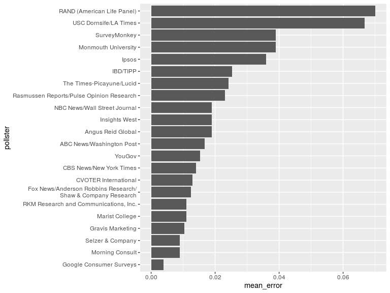

```r
library(ggplot2)
#polls %>% ggplot(aes(x = pollster, y = abs(d_hat-0.021))) + geom_col()

c <- polls %>% select(pollster, d_hat) %>% mutate(error = abs(d_hat - 0.021)) %>% select(pollster, error) %>% group_by(pollster)

#pollster끼리 절대값 error 평균

index <- c %>% count()

kuku <- function(i){
  x <- which(c$pollster %in% index$pollster[i])
  mean(c$error[x])
}

ququ <- sapply(1:nrow(index), kuku)
qrr <- data.frame(pollster = index$pollster, count = index$n, mean_error = ququ)

qrr %>% mutate(pollster = reorder(pollster, mean_error)) %>% ggplot(aes(x = pollster, y = mean_error)) + geom_col() + coord_flip() +
  scale_x_discrete(labels = c("Google Consumer Surveys", "Morning Consult", "Selzer & Company", "Gravis Marketing", "Marist College", "RKM Research and Communications, Inc.", "Fox News/Anderson Robbins Research/
                              Shaw & Company Research", "CVOTER International", "CBS News/New York Times", "YouGov", "ABC News/Washington Post", "Angus Reid Global", "Insights West", "NBC News/Wall Street Journal", "Rasmussen Reports/Pulse Opinion Research", "The Times-Picayune/Lucid", "IBD/TIPP", "Ipsos", "Monmouth University", "SurveyMonkey", "USC Dornsife/LA Times", "RAND (American Life Panel)"))
```

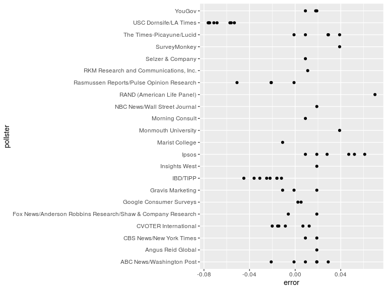

```r
polls %>% mutate(error = d_hat - 0.021) %>% ggplot(aes(x = pollster, y = error)) + geom_point()+ coord_flip()
```

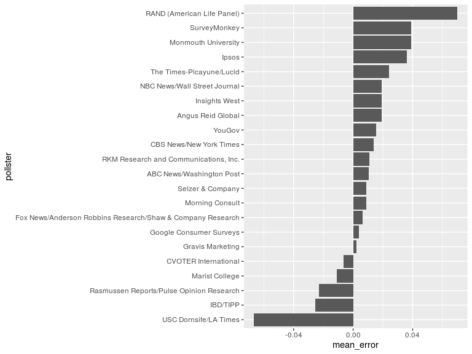

```r
c_ <- polls %>% select(pollster, d_hat) %>% mutate(error = d_hat - 0.021) %>% select(pollster, error) %>% group_by(pollster)

#pollster끼리 error 평균

index_ <- c_ %>% count()

kuku_ <- function(i){
  x <- which(c_$pollster %in% index_$pollster[i])
  mean(c_$error[x])
}

ququ_ <- sapply(1:nrow(index_), kuku_)
qrr_ <- data.frame(pollster = index_$pollster, count = index_$n, mean_error = ququ_)

qrr_ %>% mutate(pollster = reorder(pollster, mean_error)) %>% ggplot(aes(x = pollster, y = mean_error)) + geom_col() + coord_flip()
```

10. Redo the plot that you made for exercise 9, but only for pollsters that took five or more polls.

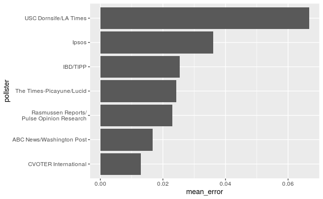

```r
qrr %>% filter(count>=5) %>% mutate(pollster = reorder(pollster, mean_error)) %>% ggplot(aes(x = pollster, y = mean_error)) + geom_col() + coord_flip() +
  scale_x_discrete(labels = c("CVOTER International", "ABC News/Washington Post", "Rasmussen Reports/
Pulse Opinion Research", "The Times-Picayune/Lucid", "IBD/TIPP", "Ipsos", "USC Dornsife/LA Times"))
```

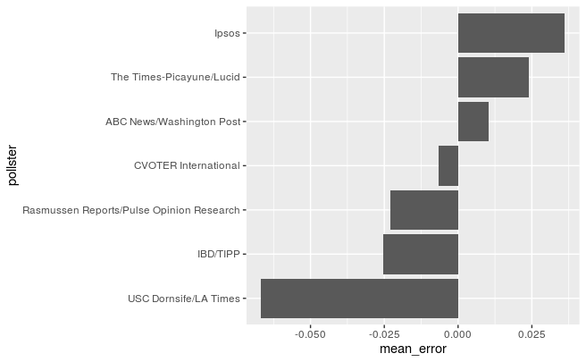

```r
qrr_ %>% filter(count>=5) %>% mutate(pollster = reorder(pollster, mean_error)) %>% ggplot(aes(x = pollster, y = mean_error)) + geom_col() + coord_flip()
```

## 15.8 Power

Pollsters are not successful at providing correct confidence intervals, but rather at predicting who will win. When we took a 25 bead sample size, the confidence interval for the spread:

```r
N <- 25
x_hat <- 0.48
(2 * x_hat - 1) + c(-1.96, 1.96) * 2 * sqrt(x_hat * (1 - x_hat) / N)
```

```
[1] -0.4316863  0.3516863
```

```
#> [1] -0.432  0.352
```

includes 0. If this were a poll and we were forced to make a declaration, we would have to say it was a “toss-up”.

A problem with our poll results is that given the sample size and the value of $p$, we would have to sacrifice on the probability of an incorrect call to create an interval that does not include 0.

This does not mean that the election is close. It only means that we have a small sample size. In statistical textbooks this is called lack of *power*. In the context of polls, *power* is the probability of detecting spreads different from 0.

By increasing our sample size, we lower our standard error and therefore have a much better chance of detecting the direction of the spread.

## 15.9 p-values

p-values are ubiquitous in the scientific literature. They are related to confidence intervals so we introduce the concept here.

Let’s consider the blue and red beads. Suppose that rather than wanting an estimate of the spread or the proportion of blue, I am interested only in the question: are there more blue beads or red beads? I want to know if the spread $2p-1 > 0$.

Say we take a random sample of $N=100$ and we observe $52$ blue beads, which gives us $2X' - 1 = 0.04$. This seems to be pointing to the existence of more blue than red beads since 0.04 is larger than 0. However, as data scientists we need to be skeptical. We know there is chance involved in this process and we could get a 52 even when the actual spread is 0. We call the assumption that the spread is $2p-1= 0$ a *null hypothesis*. The null hypothesis is the skeptic’s hypothesis. We have observed a random variable $2*X' - 1 = 0.04$ and the p-value is the answer to the question: how likely is it to see a value this large, when the null hypothesis is true? So we write:

$Pr(∣X−0.5∣>0.02)$

assuming the $2p−1=0$ or $p=0.5$. Under the null hypothesis we know that:

$√N(X−0.5)/(√0.5(1−0.5))$

(Z구나.)

is standard normal. We therefore can compute the probability above, which is the p-value.

(즉 p=0.5일 때 Z값?)

$Pr(√N|X−0.5|/(√0.5(1−0.5)) > √N(0.02)/(√0.5(1−0.5)))$

```r
N <- 100
z <- sqrt(N)*0.02/0.5
1 - (pnorm(z) - pnorm(-z))
```

```
[1] 0.6891565
```

```
#> [1] 0.689
```

1 - pr(Z < z) + pr ( Z < -z) 1 - (pr( Z < z) - pr(Z < -z)) 인가..

In this case, there is actually a large chance of seeing 52 or larger under the null hypothesis.

Keep in mind that there is a close connection between p-values and confidence intervals. If a 95% confidence interval of the spread does not include 0, we know that the p-value must be smaller than 0.05.

To learn more about p-values, you can consult any statistics textbook. However, in general, we prefer reporting confidence intervals over p-values since it gives us an idea of the size of the estimate. If we just report the p-value we provide no information about the significance of the finding in the context of the problem.

## 15.10 Association tests

The statistical tests we have studied up to now leave out a substantial portion of data types. Specifically, we have not discussed inference for binary, categorical, and ordinal data. To give a very specific example, consider the following case study.

A 2014 PNAS paper analyzed success rates from funding agencies in the Netherlands and concluded that their:

`results reveal gender bias favoring male applicants over female applicants in the prioritization of their “quality of researcher” (but not “quality of proposal”) evaluations and success rates, as well as in the language use in instructional and evaluation materials.`

The main evidence for this conclusion comes down to a comparison of the percentages. Table S1 in the paper includes the information we need. Here are the three columns showing the overall outcomes:

```r
library(tidyverse)
library(dslabs)
data("research_funding_rates")
research_funding_rates %>% select(discipline, applications_total,
                                  success_rates_total) %>% head()
```

|  | discipline | applications_total | success_rates_total |
| --- | --- | --- | --- |
| 1 | Chemical sciences | 122 | 26.2 |
| 2 | Physical sciences | 174 | 20.1 |
| 3 | Physics | 76 | 26.3 |
| 4 | Humanities | 396 | 16.4 |
| 5 | Technical sciences | 251 | 17.1 |
| 6 | Interdisciplinary | 183 | 15.8 |

We have these values for each gender:

```r
names(research_funding_rates)
```

```
 [1] "discipline"          "applications_total"  "applications_men"
 [4] "applications_women"  "awards_total"        "awards_men"
 [7] "awards_women"        "success_rates_total" "success_rates_men"
[10] "success_rates_women"
```

We can compute the totals that were successful and the totals that were not as follows:

```r
totals <- research_funding_rates %>%
  select(-discipline) %>%
  summarize_all(sum) %>%
  summarize(yes_men = awards_men,
            no_men = applications_men - awards_men,
            yes_women = awards_women,
            no_women = applications_women - awards_women)
```

So we see that a larger percent of men than women received awards:

```r
totals %>% summarize(percent_men = yes_men/(yes_men+no_men),
                     percent_women = yes_women/(yes_women+no_women))
```

| percent_men | percent_women |
| --- | --- |
| 0.17737 | 0.1489899 |

But could this be due just to random variability? Here we learn how to perform inference for this type of data.

### 15.10.1 Lady Tasting Tea

R.A. Fisher was one of the first to formalize hypothesis testing. The “Lady Tasting Tea” is one of the most famous examples.

The story is as follows: an acquaintance of Fisher’s claimed that she could tell if milk was added before or after tea was poured. Fisher was skeptical. He designed an experiment to test this claim. He gave her four pairs of cups of tea: one with milk poured first, the other after. The order was randomized. The null hypothesis here is that she is guessing. Fisher derived the distribution for the number of correct picks on the assumption that the choices were random and independent.

As an example, suppose she picked 3 out of 4 correctly. Do we believe she has a special ability? The basic question we ask is: if the tester is actually guessing, what are the chances that she gets 3 or more correct? Just as we have done before, we can compute a probability under the null hypothesis that she is guessing 4 of each. Under this null hypothesis, we can think of this particular example as picking 4 balls out of an urn with 4 blue (correct answer) and 4 red (incorrect answer) balls. Remember, she knows that there are four before tea and four after.

Under the null hypothesis that she is simply guessing, each ball has the same chance of being picked. We can then use combinations to figure out each probability. The probability of picking 3 is $(4 3)(41)/(84) = 16/70$(행렬). The probability of picking all 4 correct is $(44)(40)/(84) = 1/70$. Thus, the chance of observing a 3 or something more extreme, under the null hypothesis, is $≈0.24$. This is the p-value. The procedure that produced this p-value is called *Fisher’s exact test* and it uses the *hypergeometric distribution*.

### 15.10.2 Two-by-two tables

The data from the experiment is usually summarized by a table like this:

```r
tab <- matrix(c(3,1,1,3),2,2)
rownames(tab)<-c("Poured Before","Poured After")
colnames(tab)<-c("Guessed before","Guessed after")
tab
```

```
              Guessed before Guessed after
Poured Before              3             1
Poured After               1             3
```

These are referred to as a two-by-two table. For each of the four combinations one can get with a pair of binary variables, they show the observed counts for each occurrence.

The function `fisher.test` performs the inference calculations above:

```r
fisher.test(tab, alternative="greater")$p.value
```

```
[1] 0.2428571
```

### 15.10.3 Chi-square Test

Notice that, in a way, our funding rates example is similar to the Lady Tasting Tea. However, in the Lady Tasting Tea example, the number of blue and red beads is experimentally fixed and the number of answers given for each category is also fixed. This is because Fisher made sure there were four cups with milk poured before tea and four cups with milk poured after and the lady knew this, so the answers would also have to include four befores and four afters. If this is the case, the sum of the rows and the sum of the columns are fixed. This defines constraints on the possible ways we can fill the two by two table and also permits us to use the hypergeometric distribution. In general, this is not the case. Nonetheless, there is another approach, the Chi-squared test, which is described below.

Imagine we have 290, 1,345, 177, 1,011 applicants, some are men and some are women and some get funded, whereas others don’t. We saw that the success rates for men and woman were:

```r
totals %>% summarize(percent_men = yes_men/(yes_men+no_men),
                     percent_women = yes_women/(yes_women+no_women))
```

| percent_men | percent_women |
| --- | --- |
| 0.17737 | 0.1489899 |

respectively. Would we see this again if we randomly assign funding at the overall rate:

```r
rate <- totals %>%
  summarize(percent_total =
              (yes_men + yes_women)/
              (yes_men + no_men +yes_women + no_women)) %>%
  pull(percent_total)
rate
```

```
[1] 0.1654269
```

The Chi-square test answers this question. The first step is to create the two-by-two data table:

```r
two_by_two <- data.frame(awarded = c("no", "yes"),
                     men = c(totals$no_men, totals$yes_men),
                     women = c(totals$no_women, totals$yes_women))
two_by_two
```

| awarded | men | women |
| --- | --- | --- |
| no | 1345 | 1011 |
| yes | 290 | 177 |

The general idea of the Chi-square test is to compare this two-by-two table to what you expect to see, which would be:

```r
data.frame(awarded = c("no", "yes"),
       men = (totals$no_men + totals$yes_men) * c(1 - rate, rate),
       women = (totals$no_women + totals$yes_women) * c(1 - rate, rate))
```

| awarded | men | women |
| --- | --- | --- |
| no | 1364.5271 | 991.4729 |
| yes | 270.4729 | 196.5271 |

We can see that more men than expected and fewer women than expected received funding. However, under the null hypothesis these observations are random variables. The Chi-square test tells us how likely it is to see a deviation this large or larger. This test uses an asymptotic result, similar to the CLT, related to the sums of independent binary outcomes. The R function `chisq.test` takes a two-by-two table and returns the results from the test:

```r
chisq_test <- two_by_two %>% select(-awarded) %>% chisq.test()
```

We see that the p-value is 0.0509:

```r
chisq_test$p.value
```

```
[1] 0.05091372
```

### 15.10.4 The odds ratio

An informative summary statistic associated with two-by-two tables is the odds ratio. Define the two variables as $X=1$ if you are a male and 0 otherwise, and $Y=1$ if you are funded and 0 otherwise. The odds of getting funded if you are a man is defined:

$Pr(Y=1∣X=1)/Pr(Y=0∣X=1)$

and can be computed like this:

```r
odds_men <- with(two_by_two, (men[2]/sum(men)) / (men[1]/sum(men)))
odds_men
```

```
[1] 0.2156134
```

(290/1635)/(1345/1635)

And the odds of being funded if you are a woman is:

$Pr(Y=1∣X=0)/Pr(Y=0∣X=0)$

and can be computed like this:

```r
odds_women <- with(two_by_two, (women[2]/sum(women)) / (women[1]/sum(women)))
odds_women
```

```
[1] 0.1750742
```

The odds ratio is the ratio for these two odds: how many times larger are the odds for men than for women?

```r
odds_men / odds_women
```

```
[1] 1.231554
```

In this case, the odds ratio is $(a/c)/(b/d)$ which is equivalent to $(ad)/(bc)$

### 15.10.5 Confidence intervals for the odds ratio

Computing confidence intervals for the odds ratio is not mathematically straightforward. Unlike other statistics, for which we can derive useful approximations of their distributions, the odds ratio is not only a ratio, but a ratio of ratios. Therefore, there is no simple way of using, for example, the CLT.

However, statistical theory tells us that when all four entries of the two-by-two table are large enough, then the log of the odds ratio is approximately normal with standard error

$√1/a+1/b+1/c+1/d$

This implies that a 95% confidence interval for the log odds ratio can be formed by:

$log(ad/bc)±1.96√1/a+1/b+1/c+1/d$

By exponentiating these two numbers we can construct a confidence interval of the odds ratio.

Using R we can compute this confidence interval as follows:

```r
log_or <- log(odds_men / odds_women)
se <- two_by_two %>% select(-awarded) %>%
  summarize(se = sqrt(sum(1/men) + sum(1/women))) %>%
  pull(se)
ci <- log_or + c(-1,1) * qnorm(0.975) * se
#sum(1/men) ~> 1/a + 1/c
#qnorm(0.975) = 1.96
```

If we want to convert it back to the odds ratio scale, we can exponentiate:

```r
exp(ci)
```

```
[1] 1.004313 1.510213
```

Note that 1 is not included in the confidence interval which must mean that the p-value is smaller than 0.05. We can confirm this using:

```r
2*(1 - pnorm(log_or, 0, se))
```

```
[1] 0.0453586
```

This is a slightly different p-value than that with the Chi-square test. This is because we are using a different asymptotic approximation to the null distribution. To learn more about inference and asymptotic theory for odds ratio, consult the *Generalized Linear Models* book by McCullagh and Nelder.

### 15.10.6 Small count correction

Note that the log odds ratio is not defined if any of the cells of the two-by-two table is 0. This is because if $a$, $b$, $c$, or $d$ is 0, the $log(ad/bc)$ is either the log of 0 or has a 0 in the denominator. For this situation, it is common practice to avoid 0s by adding 0.5 to each cell. This is referred to as the *Haldane–Anscombe correction* and has been shown, both in practice and theory, to work well.

### 15.10.7 Large samples, small p-values

As mentioned earlier, reporting only p-values is not an appropriate way to report the results of data analysis. In scientific journals, for example, some studies seem to overemphasize p-values. Some of these studies have large sample sizes and report impressively small p-values. Yet when one looks closely at the results, we realize odds ratios are quite modest: barely bigger than 1. In this case the difference may not be *practically significant* or *scientifically significant*.

Note that the relationship between odds ratio and p-value is not one-to-one. It depends on the sample size. So a very small p-value does not necessarily mean a very large odds ratio. Notice what happens to the p-value if we multiply our two-by-two table by 10, which does not change the odds ratio:

```r
two_by_two %>% select(-awarded) %>%
  mutate(men = men*10, women = women*10) %>%
  chisq.test() %>% .$p.value
```

```
[1] 2.625423e-10
```

## 15.11 Exercises

1. A famous athlete has an impressive career, winning 70% of her 500 career matches. However, this athlete gets criticized because in important events, such as the Olympics, she has a losing record of 8 wins and 9 losses. Perform a Chi-square test to determine if this losing record can be simply due to chance as opposed to not performing well under pressure.

```r
two_by_two <- data.frame(results = c("win", "lose"),
                     N_Olympics = c(500*0.7-8, 500*0.3-9),
                     Olympics = c(8, 9))
two_by_two
```

| results | N_Olympics | Olympics |
| --- | --- | --- |
| win | 342 | 8 |
| lose | 141 | 9 |

```r
chisq_test <- two_by_two %>% select(-results) %>% chisq.test()
```

```r
chisq_test$p.value
```

```
[1] 0.06712074
```

2. Why did we use the Chi-square test instead of Fisher’s exact test in the previous exercise?
1. It actually does not matter, since they give the exact same p-value.
2. Fisher’s exact and the Chi-square are different names for the same test.

**c**. Because the sum of the rows and columns of the two-by-two table are not fixed so the hypergeometric distribution is not an appropriate assumption for the null hypothesis. For this reason, Fisher’s exact test is rarely applicable with observational data.

dd. Because the Chi-square test runs faster.

**c**

3. Compute the odds ratio of “losing under pressure” along with a confidence interval.

```r
odds_Olympics <- with(two_by_two, (Olympics[2]/sum(Olympics)) / (Olympics[1]/sum(Olympics)))
odds_Olympics
```

```
[1] 1.125
```

```r
odds_N_Olympics <- with(two_by_two, (N_Olympics[2]/sum(N_Olympics)) / (N_Olympics[1]/sum(N_Olympics)))
odds_N_Olympics
```

```
[1] 0.4122807
```

```r
#the odds ratio of losing under pressure
odds_Olympics / odds_N_Olympics
```

```
[1] 2.728723
```

**2.728723**

```r
log_or <- log(odds_Olympics / odds_N_Olympics)
se <- two_by_two %>% select(-results) %>%
  summarize(se = sqrt(sum(1/Olympics) + sum(1/N_Olympics))) %>%
  pull(se)
c_i <- log_or + c(-1,1) * qnorm(0.975) * se
c_i
```

```
[1] 0.03147189 1.97619587
```

```r
exp(c_i)
```

```
[1] 1.031972 7.215243
```

1 is not included. (1.00부터도 아닌 듯. (a,b)같은 ? < <)

```r
2*(1 - pnorm(log_or, 0, se))
```

```
[1] 0.04303182
```

Q3 means p-vaule is smaller than 0.05, but Q1 shows that the p-value is larger than 0.05.

Q3~> This is a slightly different p-value than that with the Chi-square test. This is because we are using a different asymptotic approximation to the null distribution.

4. Notice that the p-value is larger than 0.05 but the 95% confidence interval does not include 1. What explains this?
1. We made a mistake in our code.
2. These are not t-tests so the connection between p-value and confidence intervals does not apply.

**c**. Different approximations are used for the p-value and the confidence interval calculation. If we had a larger sample size the match would be better.

dd. We should use the Fisher exact test to get confidence intervals.

**c**

5. Multiply the two-by-two table by 2 and see if the p-value and confidence retrieval are a better match.

```r
two_by_two_2 <- two_by_two %>%
  mutate(Olympics = Olympics*2, N_Olympics = N_Olympics*2)

two_by_two_2 %>% select(-results) %>%
  chisq.test() %>% .$p.value
```

```
[1] 0.00544228
```

```r
odds_Olympics <- with(two_by_two_2, (Olympics[2]/sum(Olympics)) / (Olympics[1]/sum(Olympics)))

odds_N_Olympics <- with(two_by_two_2, (N_Olympics[2]/sum(N_Olympics)) / (N_Olympics[1]/sum(N_Olympics)))

#the odds ratio of losing under pressure
odds_Olympics / odds_N_Olympics
```

```
[1] 2.728723
```

```r
log_or <- log(odds_Olympics / odds_N_Olympics)

se_2 <- two_by_two_2 %>%
  select(-results) %>%
  summarize(se = sqrt(sum(1/Olympics) + sum(1/N_Olympics))) %>%
  pull(se)

c_i_2 <- log_or + c(-1,1) * qnorm(0.975) * se_2
exp(c_i_2)
```

```
[1] 1.372001 5.427060
```

```r
2*(1 - pnorm(log_or, 0, se_2))
```

```
[1] 0.004216133
```

**0.00544228** & **0.004216133**

It looks great!

done!